# PG2-Informe

#### **TIEMPO DE DEMORA**

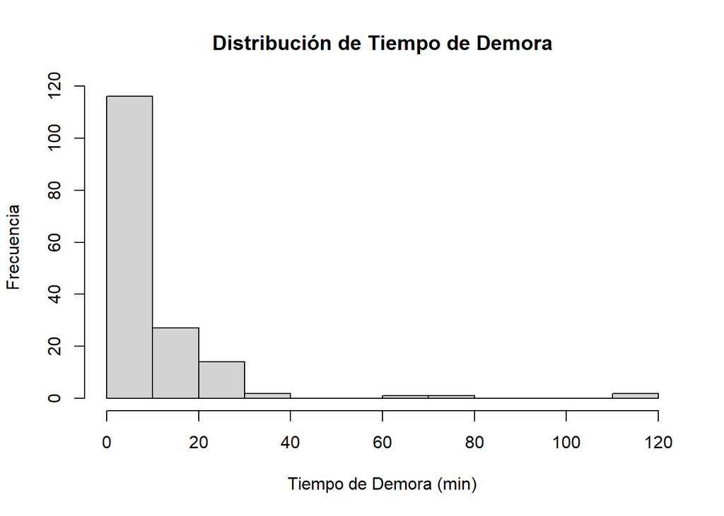

#### **TIEMPO DE DEMORA**

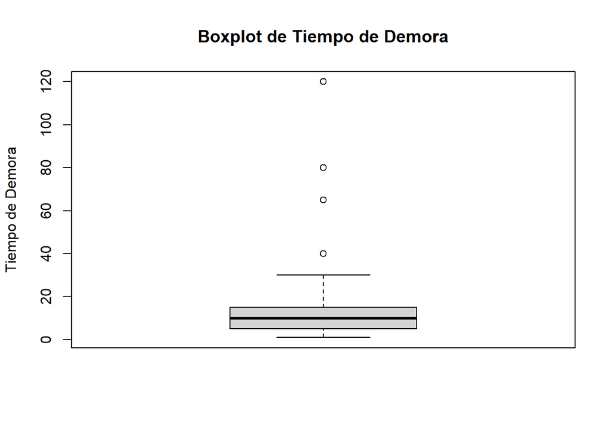

```r
boxplot(datos_filtrados1$Tiempo_de_demora,
        ylab = "Tiempo de Demora",
        main = "Boxplot de Tiempo de Demora")
```

```r
summary(datos_filtrados1$Tiempo_de_demora)
```

```
##    Min. 1st Qu.  Median    Mean 3rd Qu.    Max.
##    1.00    5.00   10.00   13.07   15.00  120.00
```

##### - **Análisis**

- El promedio nos dice que la mayoría de encuestados se demora alrededor de 13 minutos para poder buscar fuentes confiables en línea.
- Tiene un rango de 1 hasta 120 minutos, es decir, que se pueden demorar hasta 2 horas en buscar fuentes confiables.
- Hay muy pocos encuestados que sobrepasan los 30 minutos de búsqueda de fuentes confiables.

#### **NIVEL DE CONFIANZA**

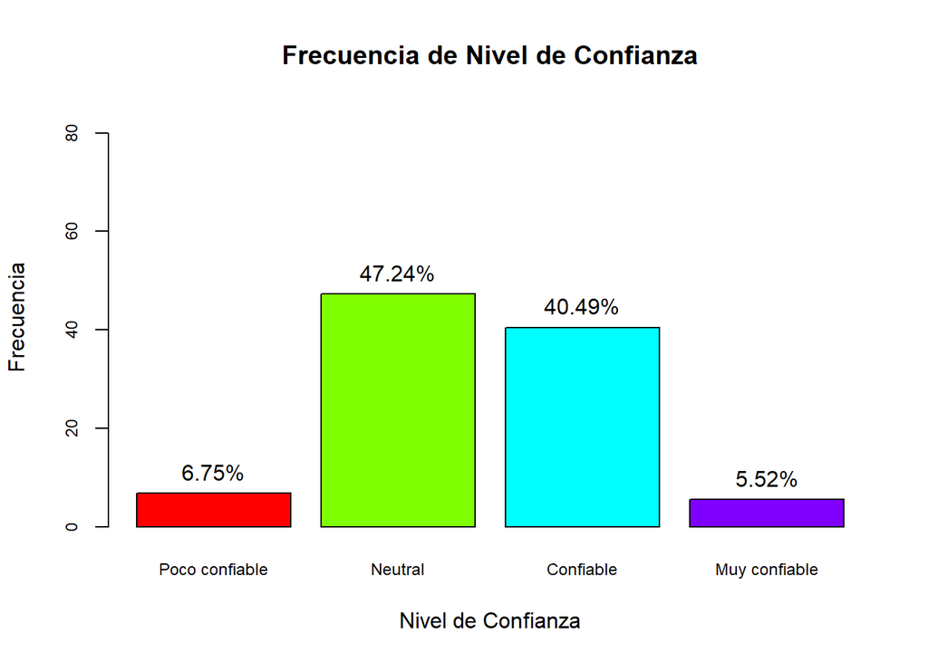